# Lake Cushman Salmon Life Cycle Models

Jacob Usinowicz

2025-02-10

[figure not shown]

## Introduction

This document presents a simplified two-stage life cycle model for salmon. This is a simplified version of the population model presented in the paper “Development of a Two-Stage Life Cycle Model for Oncorhynchus kisutch (Coho Salmon) in the Upper Cowlitz River Basin, Washington” By John M. Plumb and Russell W. Perry. It focuses on the stock-recruitment phase and the juvenile-to-adult recruitment (JAR) stage without yet going into the full depth of their model. The purpose is to demonstrate population dynamics over time using a simulation approach.

## Overview of Stock Recruitment Function

The stock-recruitment function describes the relationship between the number of spawning adults (stock) and the number of offspring that survive to the juvenile stage (recruits). This relationship is crucial for understanding population dynamics and managing fish stocks effectively.

One common model used in fisheries science is the **Ricker stock-recruitment model**, which accounts for density-dependent effects on reproduction. The function is given by:

$$R_J = E_F \alpha e^{-\beta E_F}$$

where:

- $R_J$ is the number of juvenile recruits,
- $E_F$ is the number of spawning adults,
- $\alpha$ is the productivity parameter, representing the maximum juvenile production per spawner in ideal conditions,
- $\beta$ is the density-dependent parameter, which reduces recruitment at high spawner densities.

The Ricker model is presented in its log-linearized form in Plumb and Perry (eq 1).

The Ricker model is only one of several possible stock-recruitment functions and incorporates particular assumption. In particular, it reflects the idea that while more spawners generally produce more offspring, competition for resources can limit recruitment at high densities. The Ricker model is usually particularly good for Sockeye populations because robust populations are often spawning-habitat-limited because they can get such large numbers of adult returns (like in Alaska).Too many adults can result in the loss of productivity at higher population densities of spawners. The fisheries management concept called maximum sustained yield (MSY) tries to exploit this by allowing fisheries to take the “surplus” spawners on their way to the river from the ocean to try to optimize recruitment and the number of fish that can be harvested.

## Load Required Libraries

```r
library(ggplot2)
library(gridExtra)
```

## Simulating the Ricker Model

To better understand how the Ricker model behaves, we simulate recruitment across a range of spawner abundances.

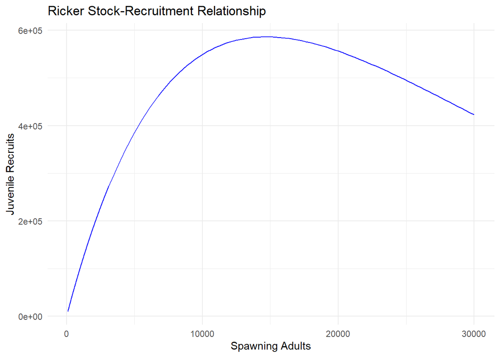

```r
# Define spawner values
E_F_vals = seq(100, 30000, length.out = 100)
alpha = 108.4
beta = 0.000068

# Compute recruitment using the Ricker model
R_J_vals = E_F_vals * alpha * exp(-beta * E_F_vals)

# Create a dataframe
df_ricker = data.frame(Spawners = E_F_vals, Recruits = R_J_vals)

# Plot the Ricker model
ricker_plot = ggplot(df_ricker, aes(x = Spawners, y = Recruits)) +
  geom_line(color = "blue") +
  labs(title = "Ricker Stock-Recruitment Relationship", x = "Spawning Adults", y = "Juvenile Recruits") +
  theme_minimal()

print(ricker_plot)
```

## Overview of Juvenile-to-Adult Recruitment Function

The second stage of the life cycle model represents the extensive environmental filter that reduces juveniles before they return and become spawners. This is often modeled as a density-independent process where a fixed proportion of juveniles survive to adulthood. The function is given by:

$$R_A = R_J \times JAR$$

where:

- $R_A$ is the number of returning adults,
- $R_J$ is the number of juveniles,
- $JAR$ is the juvenile-to-adult return rate, representing the proportion of juveniles that survive to adulthood.

This function accounts for survival rates influenced by environmental conditions, predation, and other factors affecting juvenile mortality.

## Simulating the Juvenile-to-Adult Recruitment Function

To visualize the effect of the JAR function, we simulate a range of juvenile populations and apply the return rate.

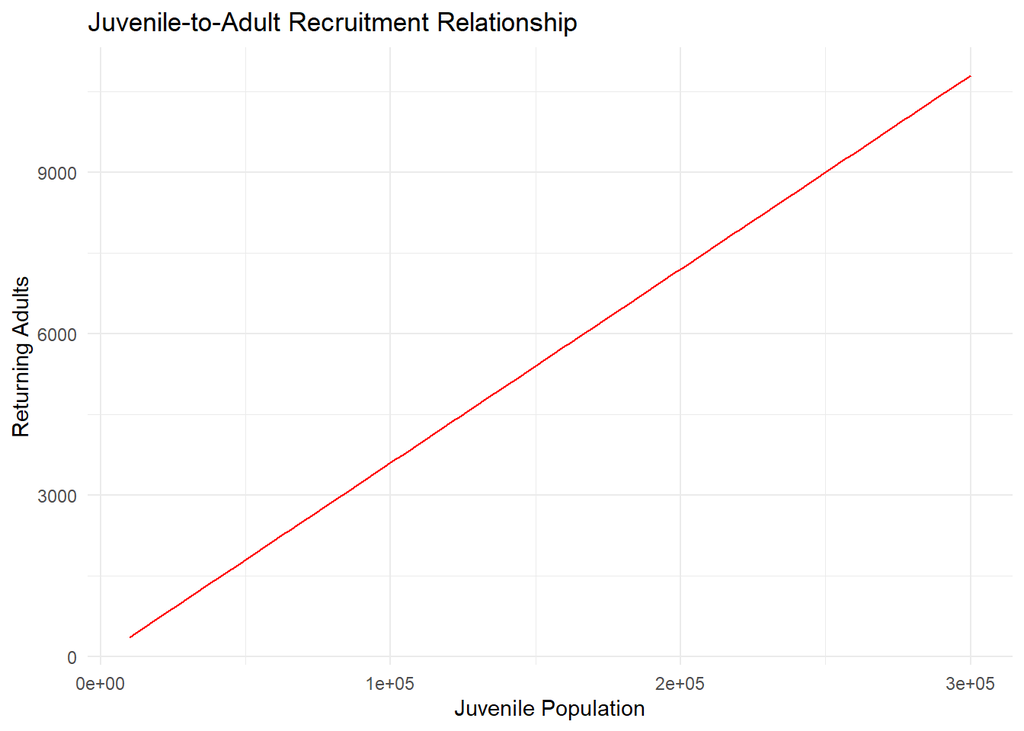

```r
# Define juvenile values
R_J_vals = seq(10000, 300000, length.out = 100)
JAR = 0.036

# Compute adult recruitment
R_A_vals = R_J_vals * JAR

# Create a dataframe
df_jar = data.frame(Juveniles = R_J_vals, Adults = R_A_vals)

# Plot the JAR function
jar_plot = ggplot(df_jar, aes(x = Juveniles, y = Adults)) +
  geom_line(color = "red") +
  labs(title = "Juvenile-to-Adult Recruitment Relationship", x = "Juvenile Population", y = "Returning Adults") +
  theme_minimal()

print(jar_plot)
```

## Define Simulation Parameters

We define the number of years for the simulation and key biological parameters. The stock-recruitment phase follows a Ricker model, while the juvenile-to-adult transition follows a log-normal recruitment model.

```r
set.seed(42)  # Ensure reproducibility

# Simulation parameters
n_years = 50  # Number of years in the simulation
alpha = 108.4  # Productivity parameter (juveniles per female spawner)
beta = 0.000068  # Capacity parameter (density dependence)
JAR = 0.036  # Juvenile-to-adult return rate
sigma_pJ = 0.3  # Process noise for juveniles
sigma_pA = 0.2  # Process noise for adults

# Generate escapement values (spawning adults)
years = 1995:(1995 + n_years - 1)
E_F = round(15000 * exp(-0.05 * (years - 2002)))  # Exponential decline
E_F = pmax(E_F, 1000)  # Ensure a minimum escapement level
```

## Simulate Population Dynamics

The model progresses through each year, calculating juvenile production based on the Ricker model and adult recruitment using the JAR parameter.

```r
# Initialize vectors for population stages
R_J = numeric(n_years)  # Juvenile population
R_A = numeric(n_years)  # Adult population

# Initial values
R_J[1:2] = exp(rnorm(2, log(120000), sigma_pJ))
R_A[1:2] = exp(rnorm(2, log(5000), sigma_pA))

# Simulate the life cycle
for (y in 3:n_years) {
  R_J[y] = exp(log(E_F[y]) + log(alpha) - beta * E_F[y] + rnorm(1, 0, sigma_pJ)) # adults
  R_A[y] = exp(log(R_J[y]) + log(JAR) + rnorm(1, 0, sigma_pA)) #JAR
}
```

## Visualization

We plot the simulated juvenile and adult populations over time to observe trends.

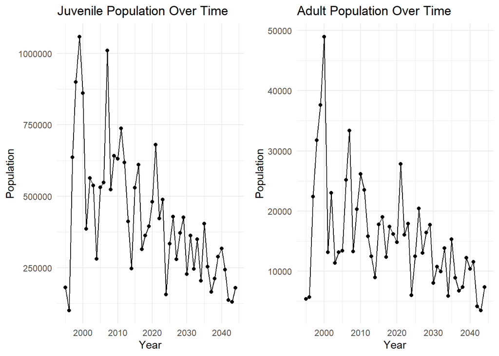

```r
df_obs = data.frame(Year = years, Juveniles = R_J, Adults = R_A)

p1 = ggplot(df_obs, aes(x = Year, y = Juveniles)) +
  geom_point() +
  geom_line() +
  labs(title = "Juvenile Population Over Time", x = "Year", y = "Population") +
  theme_minimal()

p2 = ggplot(df_obs, aes(x = Year, y = Adults)) +
  geom_point() +
  geom_line() +
  labs(title = "Adult Population Over Time", x = "Year", y = "Population") +
  theme_minimal()

grid.arrange(p1, p2, nrow = 1)
```

## Conclusion

This model provides a simple yet effective demonstration of salmon population dynamics across two life stages. It illustrates how density dependence and recruitment rates shape population trends over time.

## Additional Exploration: Environmental Variation in the Simulation

To analyze the role of environmental variation, we first run the model **without** the noise terms.

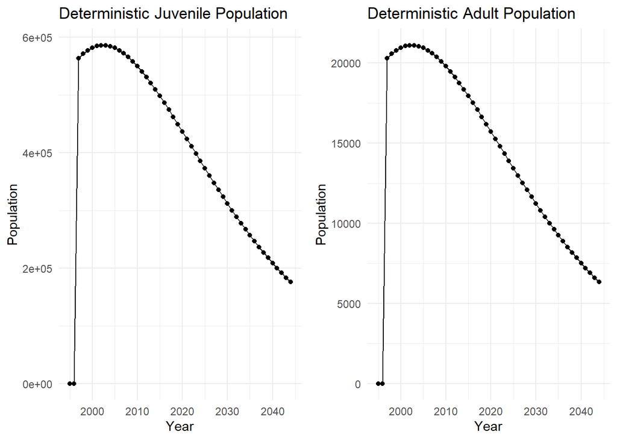

```r
# Initialize deterministic populations
R_J_det = numeric(n_years)
R_A_det = numeric(n_years)

# Simulate deterministic population dynamics
for (y in 3:n_years) {
  R_J_det[y] = exp(log(E_F[y]) + log(alpha) - beta * E_F[y])
  R_A_det[y] = exp(log(R_J_det[y]) + log(JAR))
}

# Plot deterministic population dynamics
df_det = data.frame(Year = years, Juveniles = R_J_det, Adults = R_A_det)

p3 = ggplot(df_det, aes(x = Year, y = Juveniles)) +
  geom_point() +
  geom_line() +
  labs(title = "Deterministic Juvenile Population", x = "Year", y = "Population") +
  theme_minimal()

p4 = ggplot(df_det, aes(x = Year, y = Adults)) +
  geom_point() +
  geom_line() +
  labs(title = "Deterministic Adult Population", x = "Year", y = "Population") +
  theme_minimal()

grid.arrange(p3, p4, nrow = 1)
```

## Visualizing Environmental Noise

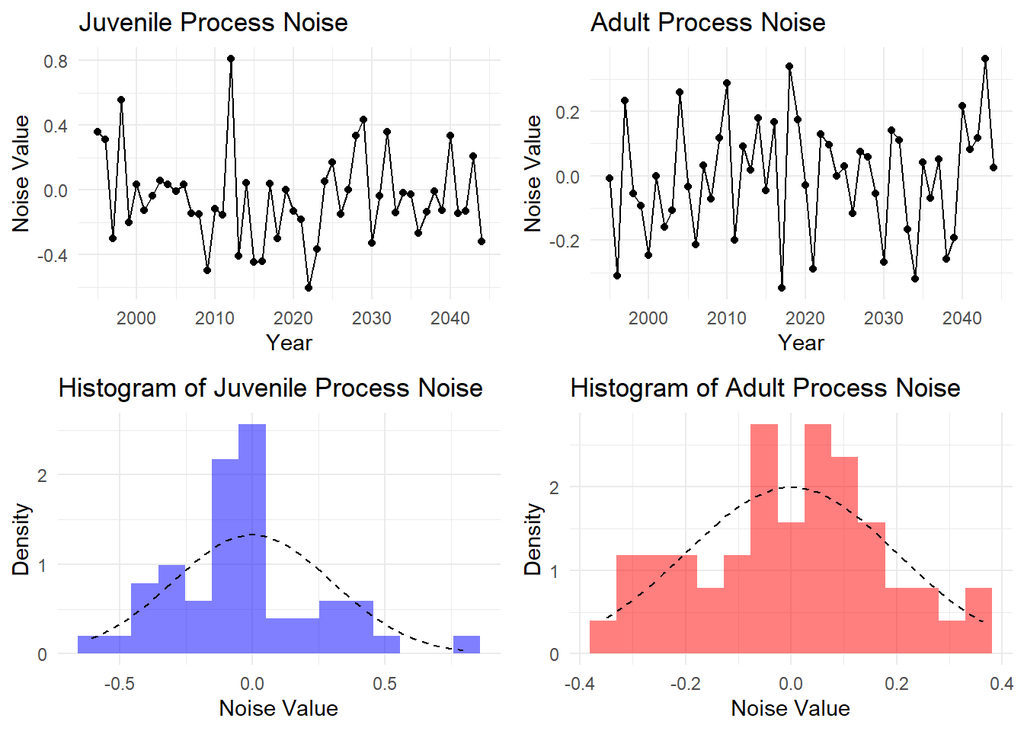

```r
# Extract noise terms
noise_J = rnorm(n_years, 0, sigma_pJ)
noise_A = rnorm(n_years, 0, sigma_pA)

df_noise = data.frame(Year = years, Juvenile_Noise = noise_J, Adult_Noise = noise_A)

p5 = ggplot(df_noise, aes(x = Year, y = Juvenile_Noise)) +
  geom_point() +
  geom_line() +
  labs(title = "Juvenile Process Noise", x = "Year", y = "Noise Value") +
  theme_minimal()

p6 = ggplot(df_noise, aes(x = Year, y = Adult_Noise)) +
  geom_point() +
  geom_line() +
  labs(title = "Adult Process Noise", x = "Year", y = "Noise Value") +
  theme_minimal()

# Plot histograms of noise terms
p7 = ggplot(df_noise, aes(x = Juvenile_Noise)) +
  geom_histogram(aes(y = ..density..), bins = 15, fill = "blue", alpha = 0.5) +
  stat_function(fun = dnorm, args = list(mean = 0, sd = sigma_pJ), color = "black", linetype = "dashed") +
  labs(title = "Histogram of Juvenile Process Noise", x = "Noise Value", y = "Density") +
  theme_minimal()

p8 = ggplot(df_noise, aes(x = Adult_Noise)) +
  geom_histogram(aes(y = ..density..), bins = 15, fill = "red", alpha = 0.5) +
  stat_function(fun = dnorm, args = list(mean = 0, sd = sigma_pA), color = "black", linetype = "dashed") +
  labs(title = "Histogram of Adult Process Noise", x = "Noise Value", y = "Density") +
  theme_minimal()

grid.arrange(p5, p6, p7, p8,  nrow = 2)
```

## References

Plumb, John M., and Russell W. Perry. “Development of a Two-Stage Life Cycle Model for Oncorhynchus Kisutch (Coho Salmon) in the Upper Cowlitz River Basin, Washington.” US Geological Survey, 2020. https://pubs.usgs.gov/publication/ofr20201068.